# Introduction to Spatial Data Types in R – Raster Data

Make sure you have the `raster` libraries installed. If not:

```
install.packages("raster")
```

## 1. Creating Raster Data From Scratch

Rasters are much more compact that vectors. Because of their regular structure the coordinates do not need to be recorded for each pixel or cell in the rectangular extent. A raster has a CRS, an origin, a distance or cell size in each direction, a dimension in terms of numbers of cells, and an array of values. If necessary, the coordinates for any cell can be computed.

Note that the `sp` library used for vector data does have some basic tools for manipulating raster data. However, the `sp` library has largely been replaced by the `raster` library we will use here, and anything one can do with the `sp` library can also be done with the `raster` library.

A raster dataset has three primary components:

- A grid, which consists of:
  - dimensions (number of rows and columns),
  - resolution (size of sides of each cell),
  - and extent (where the edges of the grid “are”)
- A set of values associated with each cell in the grid
- Projection data about how the grid relates to the physical world

It’s relatively easy to start a raster object by just defining the grid:

```r
basic_raster <- raster(ncol = 5, nrow = 10, xmn = 0, xmx = 5, ymn = 0, ymx = 10)
basic_raster
```

```
class       : RasterLayer
dimensions  : 10, 5, 50  (nrow, ncol, ncell)
resolution  : 1, 1  (x, y)
extent      : 0, 5, 0, 10  (xmin, xmax, ymin, ymax)
coord. ref. : +proj=longlat +datum=WGS84 +ellps=WGS84 +towgs84=0,0,0
```

However, note that this raster has a grid, but no data:

```r
hasValues(basic_raster)
```

```
[1] FALSE
```

We add data to the raster object using the `values` function:

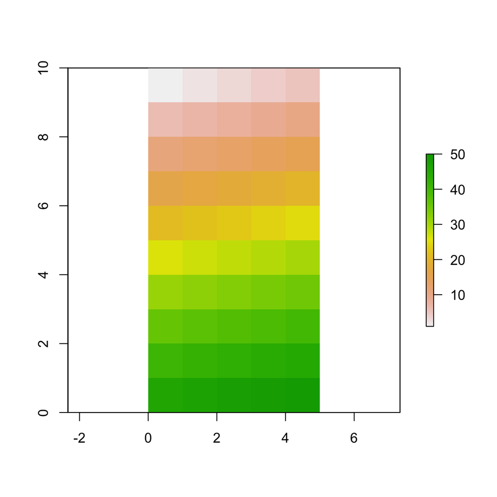

```r
values(basic_raster) <- 1:50  # Note 50 is the total number of cells in the grid.
plot(basic_raster)
```

### Defining projection

To define a projection, we use the same proj4 strings as vector data, but without the intermediate step of creating a CRS object:

```r
projection(basic_raster) <- "+init=EPSG:4326"
```

## 2. Reading Raster data from files

The `raster` library can also read many file types on it’s own.

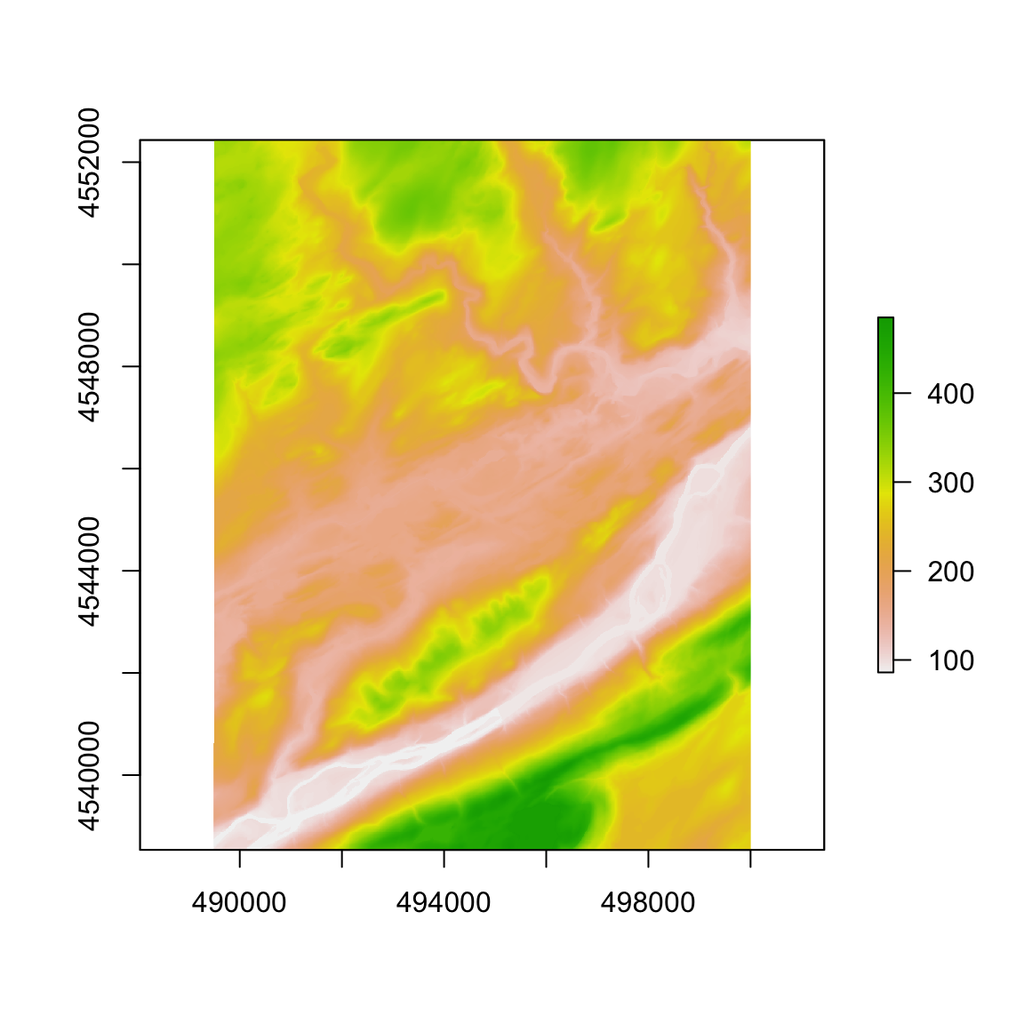

```r
raster_from_file <- raster("DEM_10m/bushkill_pa.dem")
plot(raster_from_file)
```

## 3. Modifying & Interrogating `raster` objects

`raster` comes with a number of tools for modifying a raster object:

- Change resolution: `res(basic_raster) <- c(x value,y value)`
- Change number of columns: `ncol(basic_raster) <- value`
- Change number of rows: `nrow(basic_raster) <- value`

However, **be careful with these commands** – if you change the number of columns or rows, that will necessarily change the resolution and vice versa! Moreover, **if you change the dimensions, any values associated with the data will be erased.**

Simiarly, you can call most attributes of a raster using analogous commands:

- Resolution: `res(basic_raster)`
- Dimensions: `dim(basic_raster)`
- Max X extent: `xmax(basic_raster)`
- Values: `values(basic_raster)`
- etc.

#### Exercise 1

1. Make sure your working directory is set to the `R_Workshop` folder and it contains the materials you downloaded and unzipped earlier.
2. Read in with: `raster_from_file <- raster("DEM_10m/bushkill_pa.dem")`
3. What is the extent of this raster?
4. What is the projection?
5. Plot the raster with: `plot(raster_from_file)` ***